# 贷款逾期用户画像分析

```python
from IPython.display import display
from IPython.display import HTML
import IPython.core.display as di
di.display_html('<script>jQuery(function() {if (jQuery("body.notebook_app").length == 0) { jQuery(".input_area").toggle(); jQuery(".prompt").toggle();}});</script>', raw=True)
CSS = """#notebook div.output_subarea {max-width:100%;}""" #changes output_subarea width to 100% (from 100% - 14ex)
HTML('<style>{}</style>'.format(CSS))
```

# 目录

- 项目背景和目的
  - 项目背景
  - 项目目的
- 数据获取、清洗和整理
  - 数据获取
  - 数据清洗和整理
    - 认识数据集
    - 修改数据类型
    - 检查缺失值
    - 检查重复值
    - 添加数据字段
    - 选取数据集
- 逾期贷款数据探索分析
  - 贷款逾期单特征变量分析
    - 贷款逾期用户属性特征分析(用户年龄、用户初始评级及用户性别)
    - 贷款逾期用户行为特征分析(贷款金额、贷款期限及认证情况)
  - 贷款逾期二维特征变量分析
    - 借款利率与初始评级二维特征分析
    - 借款利率与借款类型二维特征分析
  - 贷款逾期多维特征变量分析
    - 借款利率、借款类型及人均借款金额三维特征分析
    - 借款利率、借款金额及初始评级三维特征分析
- 总结及建议
  - 借款逾期用户热证总结
  - 建议

# 一 项目背景和目的

## 1.1 项目背景

- 拍拍贷成立于2007年6月，总部位于上海，是一家金融科技公司。拍拍贷平台借款端服务包括面向广大个人用户的通用性借款和其他借款，借贷流程已实现高度自动化。出借端包括散标出借和自动投标策略新彩虹，以自动投标工具等为用户带来卓越的出借体验。

## 1.2 项目目的

- 通过对拍拍贷信用标个人贷款数据进行分析，主要解决一下问题：
  - 分析出信用标个人贷款逾期还款者的基本特征。
  - 针对逾期还款者的特征，给出建议降低逾期还款率。

# 二 数据获取、清洗及整理

## 2.1 数据获取

- 本报告数据选取自[Kesci上数据集](https://www.kesci.com/home/dataset/58c614aab84b2c48165a262d/document)上拍拍贷真实业务数据，包含从2015-01-01到2017-01-30的所有信用标的10%sample样本。具体选择样本中标的特征表数据集 - LC.csv数据。

## 2.2 数据清洗及整理

### 2.2.1 导入数据，数据概览

- 将数据导入到Mysql，进行数据预览
- *SELECT* FROM lc*
- *LIMIT 14*

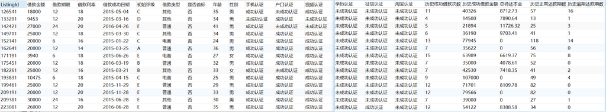

### 2.2.2 认识数据集

- LC (Loan Characteristics) 表为标的特征表，每支标一条记录。共有21个字段，包括一个主键（listingid）、7个标的特征和13个成交当时的借款人信息，全部为成交当时可以获得的信息。

```python
%%html
<img src="./数据集.png" width=400 height=300>
```

[figure not shown]

### 2.2.3 修改数据类型

- 在导入数据过程发现字段"年龄"，"借款金额"，"借款期限"，"历史成功借款次数"，"历史正常还款期数"，"历史逾期还款期数"都为字符型，为后期分析数据方便，调整字段类型为int型。
- *ALTER TABLE lc*
- *MODIFY column 借款金额 int(25) NOT NULL,*
- *MODIFY column 借款期限 int(25) not null,*
- *MODIFY column 历史成功借款次数 int(25) NOT NULL,*
- *MODIFY column 历史正常还款期数 int(25) NOT NULL,*
- *MODIFY column 历史逾期还款期数 int(25) NOT NULL,*
- *MODIFY column 年龄 int(25) NOT NULL,*
- *MODIFY column 借款利率 float(25) NOT NULL;*

```python
%%html
<img src="./修改数据类型.png" width=400 height=300>
```

[figure not shown]

### 2.2.4 检查缺失值、重复值

- 为方便后期数据分析，需检查贷款数据中是否存在缺失值，如存在缺失值，需考虑实际情况进行处理。
- *SELECT*
  - *COUNT(DISTINCT ListingId) as ListingId,COUNT(借款金额) as 借款金额,COUNT(借款期限) as 借款期限,*
  - *COUNT(借款利率) as 借款利率,COUNT(借款成功日期) as 几款成功日期,COUNT(初始评级) as 初始评级,*
  - *COUNT(借款类型) as 借款类型,COUNT(是否首标) as 是否首标,COUNT(年龄) as 年龄,*
  - *COUNT(性别) as 性别,COUNT(手机认证) as 手机认证,COUNT(户口认证) as 户口认证,*
  - *COUNT(视频认证) as 视频认证,COUNT(学历认证) as 学历认证,COUNT(征信认证) as 征信认证,*
  - *COUNT(淘宝认证) as 淘宝认证 ,COUNT(历史成功借款次数) as 历史成功借款次数,*
  - *COUNT(历史成功借款金额) as 历史成功借款金额,COUNT(总待还本金) as 总待还本金,*
  - *COUNT(历史正常还款期数) as 历史正常还款期数,COUNT(历史逾期还款期数) as 历史逾期还款期数*
- *FROM LC;*

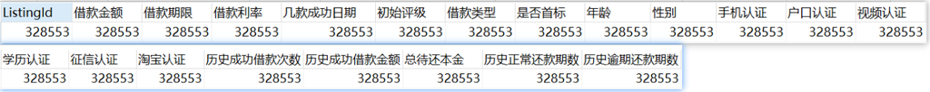

### 2.2.5 添加数据字段

- 根据字段'历史逾期还款期数'判断是否逾期，若为0，则不逾期，否则逾期。并通过SQL添加'是否逾期'数据字段，方便后期分析逾期贷款用户特征
- *ALTER TABLE lc,*
- *ADD 是否逾期 varchar(30);*
- *UPDATE lc,*
- *SET 是否逾期=CASE WHEN 历史逾期还款期数=0 THEN 0 ELSE 1 END;*

```python
%%html
<img src="./数据预览.png">
```

[figure not shown]

### 2.2.6 选取数据集

- 由于本项目主要对逾期用户进行探索性分析，根据前期添加的字段'是否逾期'，筛选出值为 1 的数据记录，建立新的数据表lcyuqi,并进行分析。
- *SELECT **
- *FROM (SELECT* FROM lc WHERE 是否逾期=1) AS a*
- *LIMIT 7*

```python
%%html
<img src="./数据预览.png">
```

[figure not shown]

# 三 逾期贷款数据探索分析

## 3.1 贷款逾期单特征变量分析

### 3.1.1 贷款逾期用户属性特征分析

- 分别从用户年龄、用户性别及用户初始评级角度进行分析

#### 3.1.1.1 逾期的情况下，用户年龄分布

- 使用以下SQL求出不同年龄段内逾期贷款人数，并对结果进行数据可视化：
- *SELECT*
  - *CASE*
  - *WHEN 年龄>= 17 AND 年龄<=25 THEN '17-25'*
  - *WHEN 年龄>= 26 AND 年龄<=35 THEN '26-35'*
  - *WHEN 年龄>= 36 AND 年龄<=45 THEN '36-45'*
  - *WHEN 年龄>= 46 AND 年龄<=56 THEN '46-56'*
  - *ELSE NULL END AS '年龄段',COUNT(历史逾期还款期数) as 人数*
- *FROM lcyuqi*
- *GROUP BY*
  - *CASE*
  - *WHEN 年龄>= 17 AND 年龄<=25 THEN '17-25'*
  - *WHEN 年龄>= 26 AND 年龄<=35 THEN '26-35'*
  - *WHEN 年龄>= 36 AND 年龄<=45 THEN '36-45'*
  - *WHEN 年龄>= 46 AND 年龄<=56 THEN '46-56'*
  - *ELSE NULL END*
- *ORDER BY 人数 DESC;*

```python
%%html
<img src="./逾期-年龄分布.png" width=400; height=300>
```

[figure not shown]

- 由上图可知，贷款逾期人数主要集中在(26-35)年龄段内，占全部逾期人数的55%。
- 但是通常情况下在(26-35)年龄段内的人被认为是社会的中坚力量，正处于事业的上升期或者黄金阶段，还远未到中年危机阶段，为什么他们反而会更容易逾期？是否是这个年龄段内的贷款总人数本身数量就大造成的？又或者这个年龄段内贷款利率比较高，还款难度比较大所以造成逾期还款？
- 接下来将从以下角度在进行分析：
  - 1 不同年龄段的贷款总人数与该年龄段内的贷款逾期人数作对比
  - 2 不同年龄段内不同借款利率人数分布进行分析。

###### 3.1.1.1.1 不同年龄段全部贷款人数及逾期贷款人数分布

- 使用以下SQL语句求出不同年龄段的贷款总量，并分析每个年龄段内逾期占比，并使用Excel绘制可视化图表：
- *SELECT*
- *CASE*
- *WHEN 年龄>= 17 AND 年龄<=25 THEN '17-25'*
- *WHEN 年龄>= 26 AND 年龄<=35 THEN '26-35'*
- *WHEN 年龄>= 36 AND 年龄<=45 THEN '36-45'*
- *WHEN 年龄>= 46 AND 年龄<=56 THEN '46-56'*
- *ELSE NULL END AS '年龄段',COUNT(历史逾期还款期数) AS '分年龄段-贷款总人数',*
- *CAST(SUM(是否逾期) AS decimal) AS '逾期人数',*
- *CONCAT(ROUND(COUNT(历史逾期还款期数)/328553*100,0),'%') AS 分段占比,*
- *CONCAT(ROUND(SUM(是否逾期)/COUNT(历史逾期还款期数)*100,0),'%') AS 逾期占比*
- *FROM lc*
- *GROUP BY*
- *CASE*
- *WHEN 年龄>= 17 AND 年龄<=25 THEN '17-25'*
- *WHEN 年龄>= 26 AND 年龄<=35 THEN '26-35'*
- *WHEN 年龄>= 36 AND 年龄<=45 THEN '36-45'*
- *WHEN 年龄>= 46 AND 年龄<=56 THEN '46-56'*
- *ELSE NULL END*
- *ORDER BY '分年龄段-贷款总人数' DESC*

```python
%%html
<img src="./分段-年龄-逾期.png" width=400; height=300>
```

[figure not shown]

- 由分析可知，(26-35)年龄段内的总贷款人数为166608人，占了全部贷款人数的51%，所以其逾期人数相对也会更多。
- 而这个年龄段内逾期贷款人数只占到此年龄段贷款人数的16.68%，相比较而言，在(36-45)年龄段内，贷款人数占总贷款人数的13%，但是逾期人数占到此年龄段人数16.74%，(46-56)年龄段内，贷款人数占总贷款人数的3%，但是逾期人数占到此年龄段人数的17.9%，均大于(26-35)年龄段的16.68%
- 所以(36-45)和(46-56)年龄段的贷款者更容易逾期还款。这也与现实情况相符，一般这个两个年龄段的人，都组建了自己的家庭，需要赡养父母和照顾子女，来自家庭和工作的压力巨大，所以对金钱的需求也会很大。

###### 3.1.1.1.2 不同年龄段高贷款利率区间人数分布

- 使用以下SQL语句求出不同年龄段不同贷款利率人数分布，并对结果进行数据可视化：
- *SELECT*
- *CASE*
- *WHEN 年龄>= 17 AND 年龄<=25 THEN '17-25'*
- *WHEN 年龄>= 26 AND 年龄<=35 THEN '26-35'*
- *WHEN 年龄>= 36 AND 年龄<=45 THEN '36-45'*
- *WHEN 年龄>= 46 AND 年龄<=56 THEN '46-56'*
- *ELSE NULL END AS '年龄段',COUNT(历史逾期还款期数) AS '分年龄段-贷款总人数',*
- *SUM(CASE*
  - *WHEN 借款利率>=15.5 AND 借款利率<=24.5 THEN 1 ELSE 0 END) AS '分段高利率人数'*
- *FROM lc*
- *GROUP BY*
- *CASE*
- *WHEN 年龄>= 17 AND 年龄<=25 THEN '17-25'*
- *WHEN 年龄>= 26 AND 年龄<=35 THEN '26-35'*
- *WHEN 年龄>= 36 AND 年龄<=45 THEN '36-45'*
- *WHEN 年龄>= 46 AND 年龄<=56 THEN '46-56'*
- *ELSE NULL END*
- *ORDER BY '分年龄段-贷款总人数' DESC*

```python
%%html
<img src="逾期-年龄-高利率.png" width=400; height=300>
```

[figure not shown]

- 由分析可知，每个年龄段内的贷款人贷款利率基本都在(15.5-24.5)之间，且在年龄段(26-35)及(17-25)区间内的高利率贷款者占据了全部贷款者83.81%，仅(26-35)年龄段内的高利率贷款者就占据了全部贷款者的50.51%。
- 所以由于贷款人数比较集中，且绝大部分都是高利率贷款，给还款造成了很大压力，这也就解释了为什么(26-35)年龄段内逾期还款者人数最多。

#### 3.1.1.2 逾期情况下，初始评级分布

- 使用以下SQL求出不同初始评级内逾期贷款人数，并对结果进行数据可视化：
- *SELECT 初始评级,COUNT(历史逾期还款期数) AS 人数*
- *FROM lcyuqi*
- *GROUP BY 初始评级*
- *ORDER BY 人数 DESC*

```python
%%html
<img src="./逾期-初始评级.png" width=400 height=300>
```

[figure not shown]

- 由分析图表可知，在逾期还款的贷款者中，初始评级为C、D的逾期还款者占了全部逾期还款者的86%。由拍拍贷给出的文档显示，初始评级从A—F，贷款逾期的可能性越高。那么从常理来说，初始评级从F-A，逾期人数应该逐步减少才对，但经初步分析发现信用评级为F的逾期还款者人数最少。
- 接下来，我们将从以下角度再进行分析:
  - 1 不同初始评级内，贷款人数的分布，来判断是否也是因为C、D评级内贷款人数太过集中造成的。

###### 3.1.1.2.1 不同初始评级的贷款人数分布

- 使用以下SQL求出不同初始评级内全部贷款人数，并对结果进行数据可视化：
- *SELECT 初始评级,COUNT(历史逾期还款期数) AS 全部贷款人数*
- *FROM lc*
- *GROUP BY 初始评级*
- *ORDER BY 人数 DESC*

```python
%%html
<img src="./全部贷款-初始评级.png" width=400 height=300>
```

[figure not shown]

- 由上图可知，初始评级在C、D的贷款者总人数占据了全部贷款人数的81.13%，而其余评级的贷款者总人数仅占全部贷款者的18.87%，所以由于样本基数大的原因，初始评级为C、D的逾期贷款客户占据全部贷款逾期客户的86%。

#### 3.1.1.3 逾期情况下，贷款者性别分布

- 使用以下SQL求出不同性别逾期贷款人数，并对结果进行数据可视化：
- *SELECT 性别,COUNT(历史逾期还款期数) AS 人数*
- *FROM lcyuqi*
- *GROUP BY 性别*
- *ORDER BY 人数 DESC*

```python
%%html
<img src="./逾期-性别.png" width=400 height=300>
```

[figure not shown]

- 由分析可知，在全部逾期还款者中，女性占据了35%，男性占据了65%。初步说明在还款信用方面，女性明显高于男性。
- 但真实的情况是这样吗，是否有其它因素影响？虽然在正常的认知里，女性相对男性而言更加保守，男性则更加激进。女性更容易遵守规则，男性更倾向于打破规则。考虑到本报告所分析的贷款形式是网上借贷，是否正是男女不同的性格特点导致了对网络借贷的接受程度不一样，也就是说样本本身的男女比例就相差很大？
- 基于以上假设，我们将从
  - 1 全体样本贷款数据中男女比例进行分析。
  - 2 非首次使用此贷款平台的男女比例来进行分析。

###### 3.1.1.3.1 全部贷款者的性别分布

- 使用以下SQL语句求出全部贷款数据中不同性别的贷款人数，并对结果进行数据可视化：
- *SELECT 性别,COUNT(性别) AS 人数*
- *FROM lc*
- *GROUP BY 性别*

```python
%%html
<img src="./全部-性别.png" width=400 height=300>
```

[figure not shown]

- 由分析图表可知，在全部的贷款数据中，男性占68%，女性占32%，男性是女性的2.13倍。而在逾期贷款数据中，男女比例为1.86倍。所以基本可以判断，是因为数据本身的男女比例相差就很大，所以才造成了逾期贷款数据中男女比例失衡的原因。
- 前面通过对性别、年龄及初始评级等因素的分析，可知不同情况下样本数据本身的大小对最终的分析结果起着主要作用。由于数据是拍拍贷给的官方数据，那么我们不经要提出疑问，是否给出所有的数据后，分析结果就会有所不同了？就以性别这个这特征为例，是全部样本数据中男女比例都两倍的关系还是回持平？
- 那么，在此我们假设还是会保持两倍的关系，这就提到了上面一部分我们做出的假设：是男女对网络借贷的接受程度不一样导致了样本数据中男女比例的不同，进而导致了男女逾期比例的不同。
- 所以接下来我们将从是否首标这个因素来进行分析，判断男女对网络借贷的接受程度。

###### 3.1.1.3.2 全部贷款者中，是否首标人数分布情况。

- 使用以下SQL语句求出全部贷款数据中不同性别是否首标的人数分布情况，并对结果进行数据可视化：
- *SELECT 性别,*
- *COUNT(CASE WHEN 是否首标='是' THEN 1 ELSE NULL END) AS '是首标',*
- *COUNT(CASE WHEN 是否首标='否' THEN 1 ELSE NULL END) AS '不是首标'*
- *FROM lc*
- *GROUP BY 性别*

```python
%%html
<img src="./性别-是否首标.png" width=400 height=300>
```

[figure not shown]

- 由分析图表可知，女性首标数据为占据全部数据的9%，男性首标数据为占据全部数据的17%，男性是女性的1.89倍,说明相比较而言，通过网络进行贷款的方式，男性比女性的接受程度更高。这个比率与前期分析的：男女全部样本数据比例及男女逾期样本数据比例基本保持一致，前者为男女比2.13,后者男女比1.86,现在基本可以判断是由接受度不同造成不同性别样本容量不同，进而导致逾期样本中男女比例相差较大的现象。
- 从上图中，我们还可以发现一个有趣的现象就是，在不同性别中，非首标与首标数据量之比，男性为2.93，女性为2.43,虽然相差很少，但是在样本数据量很大的情况下，人数相差还是很大的。说明男性对拍拍贷这种网络贷款方式的使用满意度更高，相较女性而言，更愿意再次尝试。由于缺乏相关数据，无法具体分析出由哪些原因导致了女性使用满意度偏低的原因。

### 3.1.2 贷款逾期用户行为特征分析

- 分别从借款金额、借款期限及认证角度进行分析

#### 3.1.2.1 逾期情况下，借款金额分布

- 为更好的分析逾期情况下的借款金额分布情况，首先需明确在全部样本数据中，借款金额是如何分布，使用以下SQL语句求出在全部样本中，借款金额的最大值和最小值
- *SELECT MIN(借款金额) AS 借款最小值 ,MAX(借款金额) AS 借款最大值*
- *FROM lc*
- 可知，最大贷款金额为500000元，最小贷款金额为100元。那么数据是如何分布的呢？使用以下SQL语句将全部样本数据进行分组，并进行数据可视化可知：
- *SELECT*
- *CASE*
- *WHEN 借款金额>=100 AND 借款金额<=100099 THEN '100-100099'*
- *WHEN 借款金额>=100100 AND 借款金额<=200099 THEN '100100-200099'*
- *WHEN 借款金额>=200100 AND 借款金额<=300099 THEN '200100-300099'*
- *WHEN 借款金额>=300100 AND 借款金额<=400099 THEN '300100-400099'*
- *WHEN 借款金额>=400100 AND 借款金额<=500099 THEN '400100-500099'*
- *ELSE NULL END AS 人数分布,COUNT(借款金额) AS 人数分布*
- *FROM LC*
- *GROUP BY*
- *CASE*
- *WHEN 借款金额>=100 AND 借款金额<=100099 THEN '100-100099'*
- *WHEN 借款金额>=100100 AND 借款金额<=200099 THEN '100100-200099'*
- *WHEN 借款金额>=200100 AND 借款金额<=300099 THEN '200100-300099'*
- *WHEN 借款金额>=300100 AND 借款金额<=400099 THEN '300100-400099'*
- *WHEN 借款金额>=400100 AND 借款金额<=500099 THEN '400100-500099'*
- *ELSE NULL END*

```python
%%html
<img src="./逾期-借款金额-全部.png" width=400 height=300>
```

[figure not shown]

- 由分析图表可知，在全部的借款数据中，99.87%的贷款者贷款金额集中在(100-100099)区间中，根据规定，借款金额在1万元以上，20万元以下的贷款，称为小额贷款。所以我们可以推断，拍拍贷的贷款形式主要以小额贷款为主。
- 根据分析数据，我们也可推断，在逾期贷款数据中，贷款金额也主要集中在这一区间，接下来我们还是利用SQL语句继续进行分析：
- *SELECT*
- *CASE*
  - *WHEN 借款金额>=100 AND 借款金额<=100099 THEN '100-100099'*
  - *WHEN 借款金额>=100100 AND 借款金额<=200099 THEN '100100-200099'*
  - *WHEN 借款金额>=200100 AND 借款金额<=300099 THEN '200100-300099'*
  - *WHEN 借款金额>=300100 AND 借款金额<=400099 THEN '300100-400099'*
  - *WHEN 借款金额>=400100 AND 借款金额<=500099 THEN '400100-500099'*
- *ELSE NULL END AS 人数分布,COUNT(借款金额) AS 人数分布*
- *FROM lcyuqi*
- *GROUP BY*
- *CASE*
  - *WHEN 借款金额>=100 AND 借款金额<=100099 THEN '100-100099'*
  - *WHEN 借款金额>=100100 AND 借款金额<=200099 THEN '100100-200099'*
  - *WHEN 借款金额>=200100 AND 借款金额<=300099 THEN '200100-300099'*
  - *WHEN 借款金额>=300100 AND 借款金额<=400099 THEN '300100-400099'*
  - *WHEN 借款金额>=400100 AND 借款金额<=500099 THEN '400100-500099'*
- *ELSE NULL END*

```python
%%html
<img src="./逾期-借款金额.png" width=400 height=300>
```

[figure not shown]

- 分析图表展示的结果与我们的前期的假设结论一致，逾期贷款金额主要分布在(100-100099)这个区间内，贷款人数占了全部逾期贷款人数的99.85%。

#### 3.1.2.2 逾期情况下，借款期限分布

- 首先使用SQL语句求出，在逾期的情况下，贷款者借款期限的最大值和最小值分别是多少：
- *SELECT MAX(借款期限) AS 最大值,MIN(借款期限) AS 最小值*
- *FROM lcyuqi*
- 由分析可知，在逾期还款数据中，贷款者最大贷款期限为24期，最小贷款期限为1期。现将贷款期限进行分段，查看不同分段内分布情况：
- *SELECT*
- *CASE*
  - *WHEN 借款期限>=1 AND 借款期限<=3 THEN '1-3'*
  - *WHEN 借款期限>=4 AND 借款期限<=6 THEN '4-6'*
  - *WHEN 借款期限>=7 AND 借款期限<=9 THEN '7-9'*
  - *WHEN 借款期限>=10 AND 借款期限<=12 THEN '10-12'*
  - *WHEN 借款期限>=16 AND 借款期限<=18 THEN '16-18'*
  - *WHEN 借款期限>=22 AND 借款期限<=24 THEN '22-24'*
- *ELSE NULL END AS 人数分布,COUNT(借款金额) AS 人数分布*
- *FROM lcyuqi*
- *GROUP BY*
- *CASE*
  - *WHEN 借款期限>=1 AND 借款期限<=3 THEN '1-3'*
  - *WHEN 借款期限>=4 AND 借款期限<=6 THEN '4-6'*
  - *WHEN 借款期限>=7 AND 借款期限<=9 THEN '7-9'*
  - *WHEN 借款期限>=10 AND 借款期限<=12 THEN '10-12'**
  - *WHEN 借款期限>=16 AND 借款期限<=18 THEN '16-18'*
  - *WHEN 借款期限>=22 AND 借款期限<=24 THEN '22-24'*
- *ELSE NULL END*

```python
%%html
<img src="./逾期-借款期限.png" width=400 height=300>
```

[figure not shown]

- 由分析图表可知，绝大部分逾期还款者的贷款期限都集中在(4-6)和(10-12)这两个区间中，前者为13890人，后者34422人。而其它贷款期限中的贷款者则要少的多。
- 其实根据图表可知，如果再加上(7-9)区间内的贷款者，可以发现(4-12)区间的贷款者占了整个逾期贷款人数的99.13%,说明逾期贷款者普遍采取短期贷款为主。
- 造成这种现象的原因可能是高额的贷款利率造成的。根据前面分析不同年龄段高利率人群分布情况可知，每个年龄段的贷款者绝大部分都处于高利率的情况。这也从侧面说明为什么贷款者都以短期贷款为主了。

#### 3.1.2.3 逾期情况下，认证条件情况分布

- 用户在进行网络贷款时，需要进行相关的认证，这也是贷款企业衡量贷款客户还款能力的重要标准，原则上完成认证种类越多的客户，说明其还款能力越强。通过观察样本数据，显示拍拍贷公司提供了六种认证方式：手机认证、户口认证、学历认证、征信认证和淘宝认证，其中最主要的是征信认证。
- 接下将分别讨论每种认证情况下，逾期人数占比。理论上在每种情况下，完成认证的逾期人数会比没有完成认证的逾期人数少。

##### 3.1.2.3.1 逾期情况下，手机认证的分布？

- 使用以下SQL语句求出手机认证情况的人数，并进行数据可视化：
- *SELECT 手机认证,COUNT(手机认证) AS 人数分布*
- *FROM lcyuqi*
- *GROUP BY 手机认证*

```python
%%html
<img src="./逾期-手机.png" width=400 height=300>
```

[figure not shown]

- 由分析图表可知，在逾期还款数据中，手机认证成功的占了64.95%，未认证成功的占35.05%。
- 这与我们前期假设正好相反，也违背常理，为什么认证了后，逾期的可能性反而会增大呢？难道又与全部的样本数据有关?成功认证的贷款者远多于未成功认证的贷款者？
- 接下来我们将：
  - 1 从全部样本数据触发，考察手机认证的分布情况。
- 使用以下SQL语句，在全部贷款数据中分析手机认证的分布情况，并将结果进行数据可视化：
- *SELECT 手机认证,COUNT(手机认证) AS 人数分布*
- *FROM lc*
- *GROUP BY 手机认证*

```python
%%html
<img src="./全部-手机.png" width=400 height=300>
```

[figure not shown]

- 由数据图表可知，在全部样本数据中，成功认证的客户只占据全部样本数据的37.44%，而未成功认证的则占62.56%。
- 这与逾期还款的数据正好相反，按照从全体样本数据来看，既然未完成认证几乎是完成认证的两倍，那么逾期情况也该未完成认证人数多才对！但是为什么逾期情况下完成认证反而几乎又是未完成认证的两倍呢？
- 看来贷款手机认证到底是否可以作为评判客户信用评级的等级标准，我们要心存疑虑了。
- 接下来我们以全部数据作为分析样本，分别从：
  - 1 不同手机认证情况下，初始评级的分布进行分析
  - 2 不同手机认证情况下，历史人均借款金额及借款次数进行分析
- 使用以下SQL语句，从全部数据出发求出，不同手机认证情况下，不同初始评级的分布情况，并将结果进行数据可视化：
- *SELECT 手机认证,*
- *SUM(CASE WHEN 初始评级='A' THEN 1 ELSE 0 END) AS A级,*
- *SUM(CASE WHEN 初始评级='B' THEN 1 ELSE 0 END) AS B级,*
- *SUM(CASE WHEN 初始评级='C' THEN 1 ELSE 0 END) AS C级,*
- *SUM(CASE WHEN 初始评级='D' THEN 1 ELSE 0 END) AS D级,*
- *SUM(CASE WHEN 初始评级='E' THEN 1 ELSE 0 END) AS E级,*
- *SUM(CASE WHEN 初始评级='F' THEN 1 ELSE 0 END) AS F级*
- *FROM lc*
- *GROUP BY 手机认证*

```python
%%html
<img src="./手机认证-初始评级.png" width=400 height=300>
```

[figure not shown]

- 由分析图表可知，在所有的初始评级中，仅初始评级为F的情况下，完成手机认证的贷款用户数多于未完成认证的贷款用户数。其余评级的情况下，完成认证贷的款用户数均小于未完成手机认证的贷款用户数，完成认证的贷款用户整体信用评级越低。这说明单纯从手机认证这一评价方法来说，未起到为用户指定信用评级的作用。
- 使用以下SQL语句，从全部数据出发求出，不同手机认证情况下，历史人均还款金额及历史人均借款次数分布，并将结果进行数据可视化：
- *SELECT 手机认证,*
  - *COUNT(手机认证) AS 认证人数分布,*
  - *SUM(历史成功借款金额) AS 还款金额分布,*
  - *(SUM(历史成功借款金额)/COUNT(手机认证)) AS 人均还款金额*
- *FROM lc*
- *GROUP BY 手机认证*

```python
%%html
<img src="./贷款习惯.png" width=400 height=300>
```

[figure not shown]

- 由分析图表可知，成功完成手机认证的客户人均贷款金额为15337.3元,而未完成手机认证的客户人均贷款金额为4865.2元，前者是后者的3.15倍，说明对于完成手机认证的贷款者来说，其还款压力越大，对资金的需求力度也越大。
- 图表中还显示，完成认证的贷款次数为3.2次，未完成认证的次数为1.8次，说明完成认证的客户更习惯进行网络贷款。
- 所以综合看来：
  - 从可用贷款习惯来看，完成手机认证的客户更习惯于进行网络贷款，且人均还款压力前者是后者3.15倍。
  - 从贷款信用评级来看，除了在信用评级F中，完成认证的人数比未完成认证的人数稍多2个百分点外，其余所有评级中，前者均比后者人数少，特别是信用评级A和B中。所以总体来看，完成手机认证的贷款者整体信用评级越低。
- 综上，可以解释出为什么完成手机认证的客户相比未完成手机认证的客户更容易逾期。

##### 3.1.2.3.2 逾期情况下，户口认证的分布？

- 使用以下SQL语句求出手机认证情况的人数，并进行数据可视化：
- *SELECT 户口认证,COUNT(户口认证)*
- *FROM lcyuqi*
- *GROUP BY 户口认证*

```python
%%html
<img src="./逾期-户口认证.png" width=400 height=300>
```

[figure not shown]

- 由上图可知，逾期情况下，未完成户口认证的比例为91.58%，完成户口认证的比例为8.42%,前者远大于后者，与假设相符。

##### 3.1.2.3.3 逾期情况下，视频认证的分布？

- 使用以下SQL语句求出手机认证情况的人数，并进行数据可视化：
- *SELECT 视频认证,COUNT(视频认证)*
- *FROM lcyuqi*
- *GROUP BY 视频认证*

```python
%%html
<img src="./逾期-视频认证.png" width=400 height=300>
```

[figure not shown]

- 由上图可知，逾期情况下，未完成视频认证的比例为88.74%，完成户口认证的比例为11.26%,前者远大于后者，与假设相符。

##### 3.1.2.3.4 逾期情况下，学历认证的分布？

- 使用以下SQL语句求出手机认证情况的人数，并进行数据可视化：
- *SELECT 学历认证,COUNT(学历认证)*
- *FROM lcyuqi*
- *GROUP BY 学历认证*

```python
%%html
<img src="./逾期-学历认证.png" width=400 height=300>
```

[figure not shown]

- 由上图可知，逾期情况下，未完成学历认证的比例为58.87%，完成户口认证的比例为41.13%,前者大于后者，与假设相符。

##### 3.1.2.3.5 逾期情况下，征信认证的分布？

- 使用以下SQL语句求出手机认证情况的人数，并进行数据可视化：
- *SELECT 征信认证,COUNT(征信认证)*
- *FROM lcyuqi*
- *GROUP BY 征信认证*

```python
%%html
<img src="./逾期-征信认证.png" width=400 height=300>
```

[figure not shown]

- 由上图可知，逾期情况下，未完成征信认证的比例为94.74%，完成征信认证的比例为5.26%，前者大于后者，与假设相符。

##### 3.1.2.3.6 逾期情况下，淘宝认证的分布？

- 使用以下SQL语句求出手机认证情况的人数，并进行数据可视化：
- *SELECT 淘宝认证,COUNT(淘宝认证)*
- *FROM lcyuqi*
- *GROUP BY 淘宝认证*

```python
%%html
<img src="./逾期-淘宝认证.png" width=400 height=300>
```

[figure not shown]

## 3.2 贷款逾期二维特征变量分析

### 3.2.1 借款利率与初始评级二维特征分析

- 根据前面得到的分析结果，在全部的样本数据中，最低的贷款利率为6.5,最高的贷款利率为24。而贷款利率在(15.5-24.5)区间内，贷款人数占比为99.54%，所以绝大部门的贷款人都处于很高的贷款利率下。
- 但是具体是如何分布的呢？比如在不同初始评级下，是否评级越高，贷款利率越低？基于这一假设，我们将以逾期贷款数据为样本，进行分析。
- 使用以下SQL语句求出，在逾期情况下，不同初始评级的分组中，不同贷款利率下，贷款人数的分布情况：
- *SELECT 初始评级,*
- *SUM(CASE WHEN 借款利率>=12 AND 借款利率<15 THEN 1 ELSE NULL END) AS '[12-15)',*
- *SUM(CASE WHEN 借款利率>=15 AND 借款利率<18 THEN 1 ELSE NULL END) AS '[15-18)',*
- *SUM(CASE WHEN 借款利率>=18 AND 借款利率<21 THEN 1 ELSE NULL END) AS '[18-21)',*
- *SUM(CASE WHEN 借款利率>=21 AND 借款利率<=24 THEN 1 ELSE NULL END) AS '[21-24]'*
- *FROM lcyuqi*
- *GROUP BY 初始评级*

```python
%%html
<img src="./初始评级-利率区间.png" width=400 height=300>
```

[figure not shown]

### 3.2.1 贷款利率与借款类型二维特征分析

- 使用以下SQL语句求出，在逾期情况下，不同借款类型情况下，不同贷款利率下，贷款人数的分布情况，并对结果进行数据可是化：
- *SELECT 借款类型,*
- *SUM(CASE WHEN 借款利率>=12 AND 借款利率<15 THEN 1 ELSE NULL END) AS '[12-15)',*
- *SUM(CASE WHEN 借款利率>=15 AND 借款利率<18 THEN 1 ELSE NULL END) AS '[15-18)',*
- *SUM(CASE WHEN 借款利率>=18 AND 借款利率<21 THEN 1 ELSE NULL END) AS '[18-21)',*
- *SUM(CASE WHEN 借款利率>=21 AND 借款利率<=24 THEN 1 ELSE NULL END) AS '[21-24]'*
- *FROM lcyuqi*
- *GROUP BY 借款类型*

```python
%%html
<img src="./借款利率-借款类型.png" width=400 height=300>
```

[figure not shown]

- 由分析图表可知：
- 借款类型为APP闪电的情况下，多数贷款用户处于[21-24]利率区间内
- 借款类型为电商的情况下，多数贷款用户处于[15-18）利率区间内
- 借款类型为普通的情况下，多数贷款用户处于[18-21)利率区间内
- 借款类型为其它的情况下，多数贷款用户处于[18-21)利率区间内

## 3.3 贷款逾期三维维特征变量分析

### 3.2.1 贷款利率、借款类型及人均借款金额三维特征分析

- 使用以下SQL语句求出，在逾期情况下，不同借款类型情况下，不同贷款利率下，贷款人数的分布情况，并对结果进行数据可是化：
- *SELECT 借款类型,*
- *SUM(CASE WHEN 借款利率>=12 AND 借款利率<15 THEN 1 ELSE NULL END) AS '[12-15)',*
- *SUM(CASE WHEN 借款利率>=12 AND 借款利率<15 THEN 借款金额 ELSE NULL END) AS '[12-15)-借款金额',*
- *SUM(CASE WHEN 借款利率>=15 AND 借款利率<18 THEN 1 ELSE NULL END) AS '[15-18)',*
- *SUM(CASE WHEN 借款利率>=15 AND 借款利率<18 THEN 借款金额 ELSE NULL END) AS '[15-18)-借款金额',*
- *SUM(CASE WHEN 借款利率>=18 AND 借款利率<21 THEN 1 ELSE NULL END) AS '[18-21)',*
- *SUM(CASE WHEN 借款利率>=18 AND 借款利率<21 THEN 借款金额 ELSE NULL END) AS '[18-21)-借款金额',*
- *SUM(CASE WHEN 借款利率>=21 AND 借款利率<=24 THEN 1 ELSE NULL END) AS '[21-24]',*
- *SUM(CASE WHEN 借款利率>=21 AND 借款利率<=24 THEN 借款金额 ELSE NULL END) AS '[21-24]-借款金额'*
- *FROM lcyuqi*
- *GROUP BY 借款类型*

```python
%%html
<img src="./类型-利率-人均.png" width=400 height=300>
```

[figure not shown]

- 由分析图表可知：
- 在借款类型为APP闪电的情况下，贷款客户的贷款利率分别位于[15-18)、[18-21)、[21-24]内，并且人均贷款金额基本持平，分别为1799.27、2007.68和1940.75。
- 在借款类型为电商的情况下，贷款客户的贷款利率分别位于[12-15)、[15-18)、[18-21)内，人均贷款金额[12-15)区间内最多，为243308.58。
- 在借款类型为普通的情况下，贷款客户的贷款利率分别位于[12-15)、[15-18)、[18-21)、[21-24]内，人均贷款金额依次递减，分别为8666.02,7553.51,5572.13和4172.78
- 在借款类型为其它的情况下，贷款客户的贷款利率分别位于[12-15)、[15-18)、[18-21)、[21-24]内，在[12-15)利率区间内，人均贷款金额最多，为49994.38。

### 3.2.2 借款利率、初始评级及借款金额三维特征分析

- 使用以下SQL语句求出，在逾期情况下，不同初始评级情况下，不同借款利率下，借款金额的分布情况，并对结果进行数据可是化：
- *SELECT 初始评级,*
- *SUM(CASE WHEN 借款利率>=12 AND 借款利率<15 THEN 借款金额 ELSE NULL END) AS '[12-15)-借款金额',*
- *SUM(CASE WHEN 借款利率>=15 AND 借款利率<18 THEN 借款金额 ELSE NULL END) AS '[15-18)-借款金额',***
- *SUM(CASE WHEN 借款利率>=18 AND 借款利率<21 THEN 借款金额 ELSE NULL END) AS '[18-21)-借款金额',**
- *SUM(CASE WHEN 借款利率>=21 AND 借款利率<=24 THEN 借款金额 ELSE NULL END) AS '[21-24]-借款金额',*
- *sum(借款金额)*
- *FROM lcyuqi*
- *GROUP BY 初始评级*

```python
%%html
<img src="./评级-利率-金额.png" width=400 height=300>
```

[figure not shown]

- 由分析图表可知：
- 在初始评级A中，借款率在[15-18)区间内的借款客户，借款金额占整个A评级的67.74%
- 在初始评级B中，借款率在[12-15)、[15-18)和[18-21)区间内的借款客户，借款金额占整个B评级的99.53%
- 在初始评级C中，借款率在[18-21)区间内的借款客户，借款金额占整个C评级的90.67%
- 在初始评级D中，借款率在[21-24]区间内的借款客户，借款金额占整个D评级的83.84%
- 在初始评级E中，借款率在[21-24]区间内的借款客户，借款金额占整个E评级的87.90%
- 在初始评级F中，借款率在[21-24]区间内的借款客户，借款金额占整个F评级的92.41%

# 四 总结及建议

## 4.1 借款逾期用户特征总结

- 从用户基本特征来看：
  - 年龄段在(36-45)和(46-56)两个区间内的借款者更容易逾期
  - 由于男女对网络借贷这种借款形式接受程度不同，且男性更倾向于这种借贷形式，所以从样本数量上来说，男性更容易逾期。
  - 初始评级在C、D两个评级内的借款客户，更容易逾期。
- 从用户行为特征来看：
  - 经分析可知，拍拍贷主要以小额贷款为主，所以逾期客户的借款金额主要集中在(100-100099)内
  - 借款期限在(4-6)和(10-12)区间内的客户，更容易逾期
  - 在通过对不同认证情况的分析，发现手机认证并不能起到对借款客户信用参考的作用，而其它认证手段如：户口认证、学历认证、征信认证和淘宝认证等在完成认证条件的情况下，逾期的可能性会明显降低。
- 从二维条件来看：
  - 随着初始评级不断降低(A-F)，每个初始评级内大部分借款逾期客户所处的利率区间也越来越高。
  - 从借款类型-借款利率分析来看，在不同的借款类型中，大多逾期还款的客户借款利率处于(18-21)和(21-24)区间内。

## 4.2 建议

- 对固定评级下，能确定年龄区段，性别，借款利率区间及借款周期的特征人群，结合逾期率该特性，在批复上进行降额、增加批复周期，提高利率（无空间的直接拒贷）或者拒贷的审批方式